# Determinants Influencing the Sex Ratio of Turtle Offspring

Yuechen Huang; Shiqi Zheng

Fall 2023

## Set up and Data Wrangling

```r
library(tidyverse)
library(here)
library(rotl)

Cleaned_Data <- read.csv(here("Processed/Cleaned_Data.csv"),
                         stringsAsFactors = TRUE)
theme_yh <- theme_classic(base_size = 14) +
  theme(axis.text = element_text(color = "black"),
  legend.position = "right",
  legend.text = element_text(size = 10),
  legend.title = element_text(size = 11),
  plot.title = element_text(size = rel(1.5)),
  axis.text.x = element_text(angle = 75, vjust = 1, hjust=1))



# need to think about captive/wild ; first year and last year
```

## Explore the species

### Phylogenetic tree

We used a “rotl” package to interact with the Open Tree of Life data (https://doi.org/10.1111/2041-210X.12593). First, we need to change the name of the species into something compatible with the package.

```r
Cleaned_Data$Species_names <- as.character(Cleaned_Data$Species)  # Convert factors to characters

# Replace underscores with spaces
Cleaned_Data$Species_names <- gsub("_", " ", Cleaned_Data$Species_names)

# Create a data frame that calculate the mean sex ratio of each species
Data_species <- Cleaned_Data %>% group_by(Species_names) %>%
  summarise(mean_sex_ratio = mean(Sex_ratio, na.rm = TRUE),
            SD_sex_ratio = sd(Sex_ratio, na.rm = TRUE),
            mean_humidity_sp = mean(Humidity, na.rm = TRUE),
            SD_humidity_sp = sd(Humidity, na.rm = TRUE),
            mean_temp_sp = mean(Mean_Temp, na.rm = TRUE),
            SD_temp_sp = sd(Mean_Temp, na.rm = TRUE))
write.csv(Data_species, file = here("Processed/Data_Species.csv"), row.names = FALSE) # Data regroup by species

Data_species$taxa <- rotl::tnrs_match_names(Data_species$Species_names)
tree <- tol_induced_subtree(ott_ids = ott_id(Data_species$taxa))
```

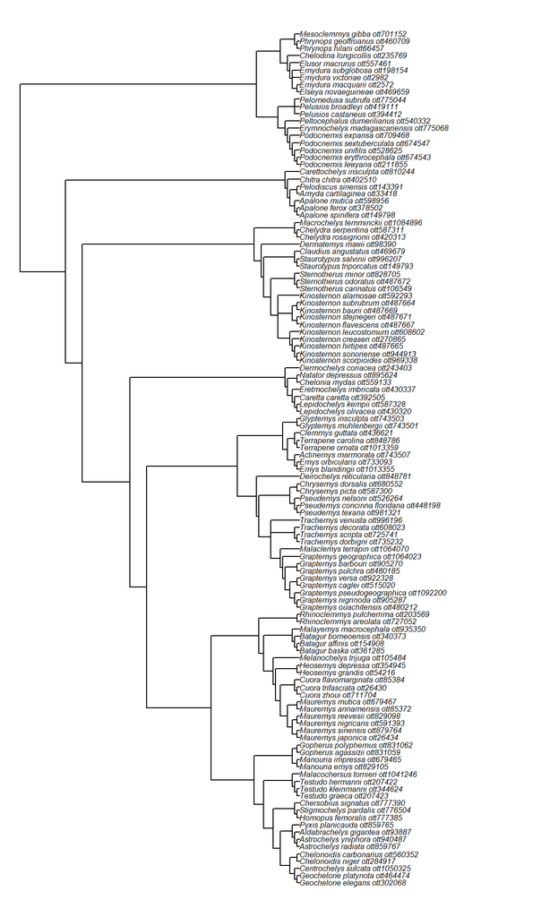

```r
collaped_tree <- ape::ladderize(ape::collapse.singles(tree, root.edge = FALSE)) ## tried to make this less messy but doesn't work
plot(collaped_tree, cex = .5, label.offset = .1, no.margin = TRUE)
```

### Tree map

Because there are too many species, the plot looks very messy…Then we can try to make a treemap instead (https://r-graph-gallery.com/236-custom-your-treemap.html).

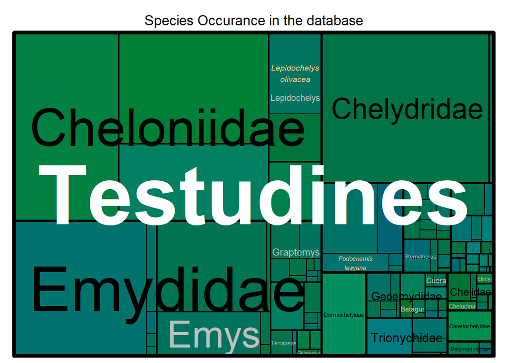

```r
library(ggplot2)
## install.packages("treemap")
# install.packages("remotes")
# remotes::install_github("d3treeR/d3treeR")
library(treemap)
library(d3treeR)

species_count <- count(Cleaned_Data, Order, Family, Genus, Species_names)
write.csv(species_count, file = here("Processed/Species_Count.csv"), row.names = FALSE)

phytree <- treemap(species_count,
        index = c("Order", "Family", "Genus", "Species_names"),
        vSize = "n",
        type = "index",
        vColor = "index",
        title="Species Occurance in the database",
        palette="Dark2",
        fontsize.labels=c(15,12,11,10),
        fontcolor.labels = c("White","Black","Grey","#ffce86"),
        fontface.labels=c(2,1,1,3),
        bg.labels=c("transparent"),
        overlap.labels= 0.15,
        inflate.labels= T,
        )
```

```r
interactive_tree <- d3tree2(phytree,
                            rootname = "Species Occurance in the database")
interactive_tree
```

[interactive chart not shown]

```r
# save the widget
library(htmlwidgets)
saveWidget(interactive_tree, file=paste0(here(), "/Processed/interactiveTreemap.html"))
```

From the tree maps (ggplot map and interactive tree map) we can see that all of the species are within Testudines Order. The most abundant family is Cheloniidae, Emydidae and Chelydridae. The species we have most in our database is Common snapping turtle (Chelydra serpentina) and Green sea turtle (Chelonia mydas) with a occurrence of 1123 and 881 records.

### Basic statistics about species

We will explore sex ratio and temperature data for different species respectively.

#### Sex ratio among species

First, we need to filter the data because we have too many species. Let’s only focus on species that have more than 100 records in our data base

```r
filtered_sp_df <- filter(species_count, n >= 100)
Sp_100 <- filtered_sp_df$Species_names
Sp_100
```

```
##  [1] "Caretta caretta"        "Chelonia mydas"         "Eretmochelys imbricata"
##  [4] "Lepidochelys kempii"    "Lepidochelys olivacea"  "Natator depressus"
##  [7] "Chelydra serpentina"    "Dermochelys coriacea"   "Chrysemys picta"
## [10] "Emys orbicularis"       "Trachemys scripta"      "Podocnemis expansa"
```

```r
sp_100_sp <- filter(Data_species, Species_names
  %in% Sp_100) # Data regroup by species and only species that have 100 records are included
sp_100_data <- filter(Cleaned_Data, Species_names
  %in% Sp_100) # Whole cleaned data and only species that have more than 100 records are included

#ggplot(Data_species, aes(x = ))
```

#### Temperature among species

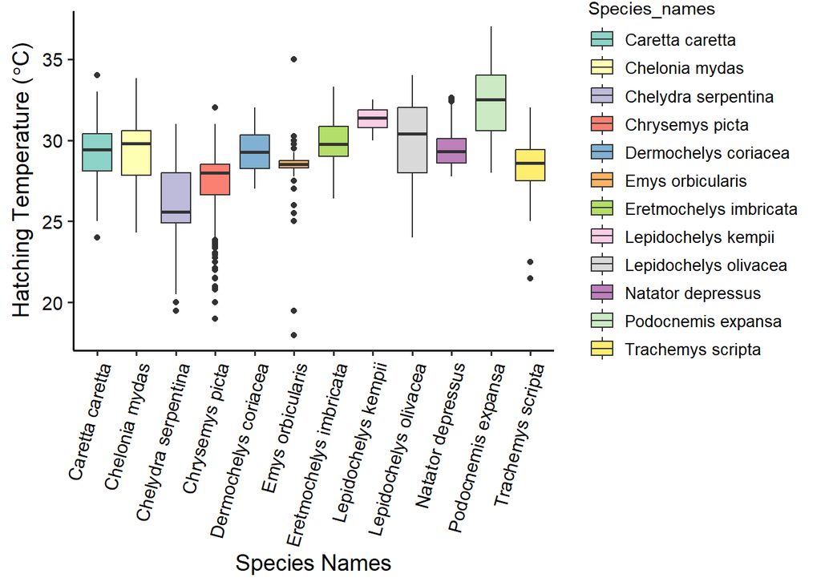

```r
ggplot(sp_100_data, aes(x = Species_names, y = Mean_Temp,
                      fill = Species_names,
                      label = Mean_Temp)) +
  geom_boxplot(na.rm = TRUE) + theme_yh +
  scale_fill_brewer(palette="Set3") +
  labs(x = "Species Names", y = expression("Hatching Temperature ("*~degree*C*")"))
```

```r
  # + geom_text(aes(label = round(mean_temp_sp, 2)), vjust = -0.5)
```